# Data_analysis

## 4. Cluster Analysis of Flowing Tributaries

Justification for using K means clustering method is explained in the manuscript.

K means clustering is an unsupervised machine learning algorithm (MLA) that partitions the dataset into a predetermined number of clusters where each data point belongs to the cluster with the nearest centroid.

The number of clusters must be chosen to run K means, which can be determined by the elbow point in the PCA scree plot (in our case, 2).

The MLA randomly begins at different initial centroids (initialization), thus the results differ from run to run. To ensure the same sequence of “random” centroid selections, we set the seed at 123 to ensure reproducibility.

We chose an arbitrary number of 50 runs from which the solution with the lowest within-cluster sum of squares was chosen.

The results will assign a 1 or 2 to each observation which corresponds to the cluster it was assigned to.

```r
# Run k-means
set.seed(123)
kmeans_result <- kmeans(scaled_blm_predict, centers = 2, nstart = 50)

# Add cluster labels to your data
flowing_tribs <- flowing_tribs %>%
  mutate(cluster = as.factor(kmeans_result$cluster))

# Check
str(flowing_tribs$cluster)
```

```
##  Factor w/ 2 levels "1","2": 1 2 2 2 2 1 2 2 1 2 ...
```

If the PCA object has not been created - run this

```r
pca_result <- prcomp(scaled_blm_predict, center = TRUE, scale. = TRUE)

summary(pca_result)
```

```
## Importance of components:
##                           PC1    PC2    PC3    PC4     PC5     PC6     PC7
## Standard deviation     1.6708 1.3157 1.0860 0.9395 0.77896 0.62646 0.54829
## Proportion of Variance 0.3489 0.2164 0.1474 0.1103 0.07585 0.04906 0.03758
## Cumulative Proportion  0.3489 0.5653 0.7128 0.8231 0.89892 0.94798 0.98556
##                            PC8
## Standard deviation     0.33990
## Proportion of Variance 0.01444
## Cumulative Proportion  1.00000
```

Overlay the clusters on the PCA biplot of flowing tributaries

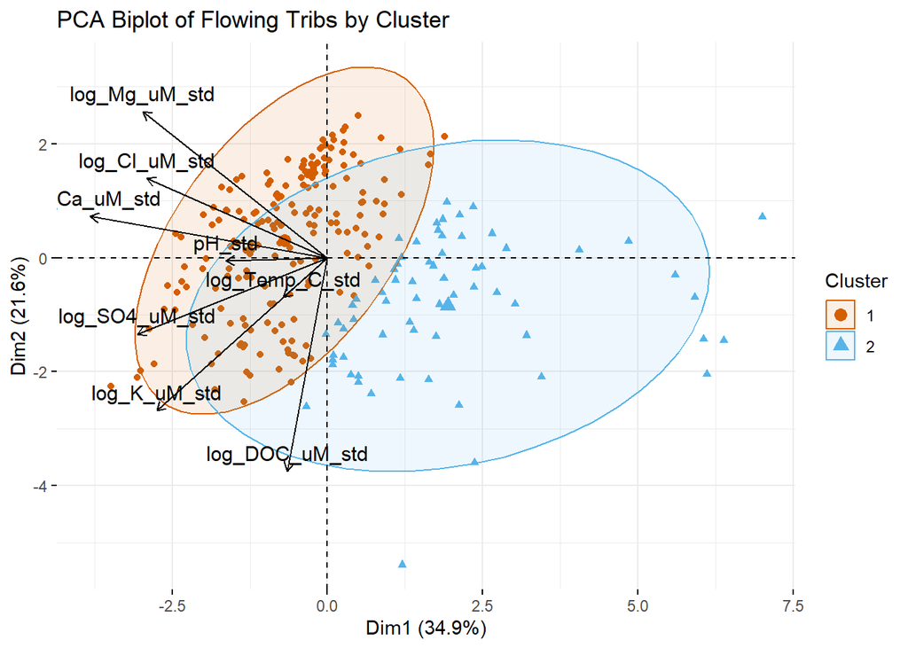

```r
# First assign factor levels
flowing_tribs$cluster <- factor(flowing_tribs$cluster, levels = c("1", "2"))

library(factoextra)

pca_cluster <- fviz_pca_biplot(
  pca_result,
  geom.ind    = "point",                      # points for sites
  col.var     = "black",                      # arrows in black
  habillage   = flowing_tribs$cluster,  # color by cluster
  addEllipses = TRUE,                         # cluster ellipses
  palette     = c("#D55E00", "#56B4E9"),      # one color per cluster
  legend.title = "Cluster"
) +
  labs(title = "PCA Biplot of Flowing Tribs by Cluster")

pca_cluster
```

Save plot

```r
ggsave("Plots of All Flowing Tribs (pre-Typology)/PCA_by_Cluster.png", plot = pca_cluster, width = 8, height = 6, units = "in", dpi = "print")
```

## 5. Characterizing Clusters

First, factorize the clusters

```r
# Development: from low to high
dat$Development <- factor(dat$Development,
                          levels = c("Low",
                                     "Medium",
                                     "High"))

# Drainage area: from small to large
dat$Drainage_area <- factor(dat$Drainage_area,
                            levels = c("<0.94 km2",
                                       "0.94-11.81 km2",
                                       ">11.81 km2"))

# Orientation: from North to South
dat$Orientation <- factor(dat$Orientation,
                          levels = c("North slope",
                                     "Main stem",
                                     "South slope"))

# Distance from main stem: from close to far
dat$Distance_from_EFPC <- factor(dat$Distance_from_EFPC,
                                 levels = c("Main stem",
                                 "<0.22 km",
                                 "0.22-0.99 km",
                                 ">0.99 km"))

# Relative elevation: from low to high
dat$Relative_elevation <- factor(dat$Relative_elevation,
                                 levels = c(
                                   "0 m",
                                   "<2.1 m",
                                   "2.1-10.5 m",
                                   ">10.5 m"))

# Checks
levels(dat$Development)
```

```
## [1] "Low"    "Medium" "High"
```

```r
levels(dat$Drainage_area)
```

```
## [1] "<0.94 km2"      "0.94-11.81 km2" ">11.81 km2"
```

```r
levels(dat$Orientation)
```

```
## [1] "North slope" "Main stem"   "South slope"
```

```r
levels(dat$Distance_from_EFPC)
```

```
## [1] "Main stem"    "<0.22 km"     "0.22-0.99 km" ">0.99 km"
```

```r
levels(dat$Relative_elevation)
```

```
## [1] "0 m"        "<2.1 m"     "2.1-10.5 m" ">10.5 m"
```

### a. Relative Frequency by Inherent Characteristics

Frequency table by inherent characteristics (Variable)

```r
library(dplyr)
library(tidyr)

# inherent characteristics
site_char <- c("Regime", "Development", "Orientation", "Distance_from_EFPC", "Drainage_area", "Relative_elevation")

cluster_summary_table_pct <- flowing_tribs %>%
  dplyr::select(all_of(site_char), cluster) %>%
  pivot_longer(
    cols = -cluster,
    names_to = "Variable",
    values_to = "Value"
  ) %>%
  count(Variable, cluster, Value, name = "Freq") %>%
  group_by(Variable, cluster) %>%
  mutate(RelFreq = prop.table(Freq) * 100)

cluster_summary_table_pct
```

| Variable | cluster | Value | Freq | RelFreq |
| --- | --- | --- | --- | --- |
| Development | 1 | High | 95 | 51.630435 |
| Development | 1 | Low | 50 | 27.173913 |
| Development | 1 | Medium | 39 | 21.195652 |
| Development | 2 | High | 3 | 4.545455 |
| Development | 2 | Low | 36 | 54.545455 |
| Development | 2 | Medium | 27 | 40.909091 |
| Distance_from_EFPC | 1 | 0.22-0.99 km | 95 | 51.630435 |
| Distance_from_EFPC | 1 | <0.22 km | 50 | 27.173913 |
| Distance_from_EFPC | 1 | >0.99 km | 39 | 21.195652 |
| Distance_from_EFPC | 2 | 0.22-0.99 km | 37 | 56.060606 |

[output cut: 21 more lines]

Save to excel

```r
library(openxlsx)

# Load the existing workbook
wb <- loadWorkbook("Statistical_analyses_flowing_tribs.xlsx")

# Create sheet if it does NOT exist
if(!"Freq by Clust" %in% names(wb)) {
  addWorksheet(wb, "Freq by Clust")
}

# Write your new table
writeData(wb, "Freq by Clust", cluster_summary_table_pct)

# Save the workbook (overwrite)
saveWorkbook(wb, "Statistical_analyses_flowing_tribs.xlsx", overwrite = TRUE)
```

Now we’ll visualize these as frequency plots of stream inherent characteristics by cluster

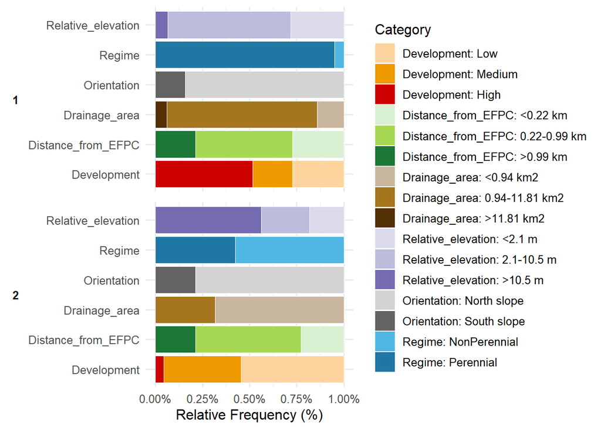

```r
library(dplyr)
# Combine variable and value
cluster_summary_table_pct <- cluster_summary_table_pct %>%
  mutate(Value_labeled = paste0(Variable, ": ", Value))

# Change the order of Variable Values
cluster_summary_table_pct$Value_labeled <- factor(
  cluster_summary_table_pct$Value_labeled,
  levels = c(
    # Development
    "Development: Low",
    "Development: Medium",
    "Development: High",

    # Distance_from_EFPC
    "Distance_from_EFPC: <0.22 km",
    "Distance_from_EFPC: 0.22-0.99 km",
    "Distance_from_EFPC: >0.99 km",

    # Drainage_area
    "Drainage_area: <0.94 km2",
    "Drainage_area: 0.94-11.81 km2",
    "Drainage_area: >11.81 km2",

    # Relative_elevation
    "Relative_elevation: <2.1 m",
    "Relative_elevation: 2.1-10.5 m",
    "Relative_elevation: >10.5 m",

    # Orientation
    "Orientation: North slope",
    "Orientation: South slope",

    # Regime
    "Regime: NonPerennial",
    "Regime: Perennial"
  )
)


# Create a named color vector for all Value_labeled combinations
color_map <- c(
  # Development
  "Development: Low" = "#fdd49e",
  "Development: Medium" = "orange2",
  "Development: High" = "red3",

  # Distance_from_EFPC
  "Distance_from_EFPC: <0.22 km" = "#d9f0d3",
  "Distance_from_EFPC: 0.22-0.99 km" = "#a6d854",
  "Distance_from_EFPC: >0.99 km" = "#1b7837",

  # Drainage_area
  "Drainage_area: <0.94 km2" = "#c8b69e",
  "Drainage_area: 0.94-11.81 km2" = "#a6761f",
  "Drainage_area: >11.81 km2" = "#543005",

  # Relative_elevation
  "Relative_elevation: <2.1 m" = "#dadaeb",
  "Relative_elevation: 2.1-10.5 m" = "#bcbddc",
  "Relative_elevation: >10.5 m" = "#756bb1",

  # Orientation
  "Orientation: North slope" = "lightgray",
  "Orientation: South slope" = "#636363",

  # Regime
  "Regime: NonPerennial" = "#4fb6e4",
  "Regime: Perennial" = "#1f78a4"
)

# Plot
library(ggplot2)
library(dplyr)

rel_freq <- ggplot(cluster_summary_table_pct,
       aes(y = Variable, x = RelFreq, fill = Value_labeled)) +
  geom_bar(stat = "identity", position = "fill", color = "white", linewidth = 0.2) +
  facet_wrap(~ cluster, ncol = 1, strip.position = "left") +
  scale_x_continuous(labels = scales::percent_format(scale = 1)) +
  labs(x = "Relative Frequency (%)", y = NULL, fill = "Category") +
  theme_minimal(base_size = 12) +
  theme(
  strip.placement = "outside",
  strip.text.y.left = element_text(angle = 0, face = "bold"),
  panel.spacing = unit(0.6, "lines"),
  legend.position = "right",        # move to right
  legend.box = "vertical",          # keep vertical layout
  legend.direction = "vertical"     # vertical legend
) +
guides(fill = guide_legend(ncol = 1)) + # 1 column
  scale_fill_manual(values = color_map)

rel_freq
```

Save plot

```r
ggsave("Plots of All Flowing Tribs (pre-Typology)/Relative_Freq_Plot_by_Cluster.png", plot = rel_freq, width = 8, height = 6, units = "in", dpi = "print")
```

### b. Naming Clusters

Based on these frequency plots, we were able to characterize each cluster. So we’ll rename each cluster according to its defining inherent characteristics:

- Cluster 1 will be called perennial developed flowing tributaries
- Cluster 2 was not very distinct, both perennial and non-perennial and moderate-less developed; thus we’ll refer to them as other flowing tributaries

```r
library(dplyr)

flowing_tribs <- flowing_tribs %>%
  mutate(cluster = as.character(cluster)) %>%
  mutate(cluster = dplyr::recode(
    cluster,
    `1` = "Developed Tributaries",
    `2` = "Tributaries"
  )) %>%
  mutate(cluster = as.factor(cluster)) %>%
  dplyr::select(cluster, everything())

# check
levels(flowing_tribs$cluster)
```

```
## [1] "Developed Tributaries" "Tributaries"
```

Save to excel

```r
# Save to excel, overwrite Dat tab
library(openxlsx)

# Load the existing workbook
wb <- loadWorkbook("Statistical_analyses_flowing_tribs.xlsx")

# Overwrite Dat tab to include data with cluster column
writeData(wb, "Dat", flowing_tribs)

# Save the workbook
saveWorkbook(wb, "Statistical_analyses_flowing_tribs.xlsx", overwrite = TRUE)
```

### c. Assign Typological Classification

We’ve established 4 distinct stream typologies:

- Perennial developed flowing tributaries (Cluster 1)
- All other flowing tributaries (Cluster 2)
- 3rd order EFPC main stem
- Non-perennial pooled tributaries

Merge the cluster column from flowing_tribs into dat

```r
library(dplyr)

dat <- dat %>%
  left_join(
    flowing_tribs %>% dplyr::select(Sample_ID, cluster),
    by = "Sample_ID"
  ) %>%
  dplyr::select(cluster, everything()) # move cluster to first column

# check
head(dat)
```

| cluster | Sample_ID | Site | Date | Regime | Flow_state | Network | Relative_elevation_m | Dist_from_EFPC_km | Drainage_area_km2 | Developed_lulc | Type | Development | Distance_from_EFPC | Drainage_area | Orientation | Relative_elevation | pH | Temp_C | DOC_uM | Ca_uM | Mg_uM | Na_uM | K_uM | SO4_uM | Cl_uM | DIC_uM | Zn_uM | Cu_uM | Free_Zn_M | … |
| --- | --- | --- | --- | --- | --- | --- | --- | --- | --- | --- | --- | --- | --- | --- | --- | --- | --- | --- | --- | --- | --- | --- | --- | --- | --- | --- | --- | --- | --- | --- |
| Developed Tributaries | WaDE_62 | MTN1.1 | 2023-06-23 | NonPerennial | Flowing | MTN | 3.832 | 0.205 | 1.42 | 63.59 | Tributaries | Medium | <0.22 km | 0.94-11.81 km2 | North slope | 2.1-10.5 m | 7.21 | 16.5 | 75.83 | 1498 | 458.0 | 212 | 37.0 | 38.2 | 174 | 4352 | 0.0360 | 0.002600 | 1.522121e-13 | … |
| NA | WaDE_63 | EFK13.8 | 2023-06-23 | Perennial | Flowing | EFK | 0.000 | 0.000 | 30.18 | 64.72 | Main Stem | Medium | Main stem | >11.81 km2 | Main stem | 0 m | 8.28 | 18.6 | 160.00 | 1338 | 333.0 | 295 | 54.0 | 139.0 | 172 | 955 | 0.0282 | 0.017400 | 4.059197e-13 | … |
| Tributaries | WaDE_64 | MTN4 | 2023-06-23 | Perennial | Flowing | MTN | 33.182 | 1.255 | 0.30 | 41.23 | Tributaries | Low | >0.99 km | <0.94 km2 | North slope | >10.5 m | 8.29 | 15.8 | 35.83 | 271 | 182.0 | 90 | 24.8 | 29.7 | 80 | 3223 | 0.1150 | 0.000488 | 5.126304e-13 | … |
| NA | WaDE_65 | MTN2 | 2023-06-23 | NonPerennial | Pooled | MTN | 12.872 | 0.673 | 0.74 | 54.43 | Tributaries | Medium | 0.22-0.99 km | <0.94 km2 | North slope | >10.5 m | 8.32 | 18.7 | 527.50 | 306 | 75.6 | 7 | 46.4 | 7.5 | 16 | 878 | 0.0707 | 0.035200 | 1.073178e-12 | … |
| Tributaries | WaDE_66 | MCA3.3 | 2023-06-23 | NonPerennial | Flowing | MCA | 30.455 | 0.995 | 0.16 | 58.52 | Tributaries | Medium | >0.99 km | <0.94 km2 | North slope | >10.5 m | 7.67 | 16.2 | 119.17 | 164 | 79.9 | 88 | 21.2 | 54.3 | 87 | 568 | 0.0316 | 0.000834 | 9.536256e-13 | … |
| Tributaries | WaDE_67 | MCA3.2 | 2023-06-23 | NonPerennial | Flowing | MCA | 25.535 | 0.939 | 0.22 | 56.61 | Tributaries | Medium | 0.22-0.99 km | <0.94 km2 | North slope | >10.5 m | 7.49 | 16.5 | 81.67 | 46 | 24.7 | 66 | 12.2 | 37.1 | 77 | 286 | 0.0819 | 0.003350 | 5.026322e-12 | … |

Now add labels for the main stem and pooled non-perennial sites

```r
library(dplyr)

# Assign labels accordingly
dat <- dat %>%
  mutate(cluster = case_when(
    Type == "Main Stem" ~ "Main Stem",
    Flow_state == "Pooled" ~ "Pooled Water",
    TRUE ~ as.character(cluster)
    ))

# Check
sum(is.na(dat$cluster)) # should be none
```

```
## [1] 0
```

```r
unique(dat$cluster)
```

```
## [1] "Developed Tributaries" "Main Stem"             "Tributaries"
## [4] "Pooled Water"
```

Change the name from cluster to Typology and assign levels

```r
library(dplyr)

# Rename to typology
dat <- dat %>% rename(Typology = cluster)

# Change to factor with different levels
dat$Typology <- as.factor(dat$Typology)
dat$Typology <- factor(dat$Typology, levels = c("Main Stem",
                                              "Developed Tributaries",
                                              "Tributaries",
                                              "Pooled Water"))

# check
levels(dat$Typology)
```

```
## [1] "Main Stem"             "Developed Tributaries" "Tributaries"
## [4] "Pooled Water"
```

Save as Bioavailability_Master_Spreadsheet_Clean_3.xlsx in our current working directory

```r
library(openxlsx)

# 1. Create a brand-new workbook
wb <- createWorkbook()

# 2. Add your sheet
addWorksheet(wb, "HA 10% Closed System")

# 3. Write your updated dat to the sheet
writeData(wb, sheet = "HA 10% Closed System", dat)

# 4. Save — overwrite the entire file
saveWorkbook(wb, "Bioavailability_Master_Spreadsheet_Clean_3.xlsx", overwrite = TRUE)
```

# Defining Stream Typologies

## 1. All Sites

```r
library(readxl)

dat <- read_excel("Bioavailability_Master_Spreadsheet_Clean_3.xlsx",
    sheet = "HA 10% Closed System")

head(dat)
```

| Typology | Sample_ID | Site | Date | Regime | Flow_state | Network | Relative_elevation_m | Dist_from_EFPC_km | Drainage_area_km2 | Developed_lulc | Type | Development | Distance_from_EFPC | Drainage_area | Orientation | Relative_elevation | pH | Temp_C | DOC_uM | Ca_uM | Mg_uM | Na_uM | K_uM | SO4_uM | Cl_uM | DIC_uM | Zn_uM | Cu_uM | Free_Zn_M | … |
| --- | --- | --- | --- | --- | --- | --- | --- | --- | --- | --- | --- | --- | --- | --- | --- | --- | --- | --- | --- | --- | --- | --- | --- | --- | --- | --- | --- | --- | --- | --- |
| Developed Tributaries | WaDE_62 | MTN1.1 | 2023-06-23 | NonPerennial | Flowing | MTN | 3.832 | 0.205 | 1.42 | 63.59 | Tributaries | Medium | <0.22 km | 0.94-11.81 km2 | North slope | 2.1-10.5 m | 7.21 | 16.5 | 75.83 | 1498 | 458.0 | 212 | 37.0 | 38.2 | 174 | 4352 | 0.0360 | 0.002600 | 1.522121e-13 | … |
| Main Stem | WaDE_63 | EFK13.8 | 2023-06-23 | Perennial | Flowing | EFK | 0.000 | 0.000 | 30.18 | 64.72 | Main Stem | Medium | Main stem | >11.81 km2 | Main stem | 0 m | 8.28 | 18.6 | 160.00 | 1338 | 333.0 | 295 | 54.0 | 139.0 | 172 | 955 | 0.0282 | 0.017400 | 4.059197e-13 | … |
| Tributaries | WaDE_64 | MTN4 | 2023-06-23 | Perennial | Flowing | MTN | 33.182 | 1.255 | 0.30 | 41.23 | Tributaries | Low | >0.99 km | <0.94 km2 | North slope | >10.5 m | 8.29 | 15.8 | 35.83 | 271 | 182.0 | 90 | 24.8 | 29.7 | 80 | 3223 | 0.1150 | 0.000488 | 5.126304e-13 | … |
| Pooled Water | WaDE_65 | MTN2 | 2023-06-23 | NonPerennial | Pooled | MTN | 12.872 | 0.673 | 0.74 | 54.43 | Tributaries | Medium | 0.22-0.99 km | <0.94 km2 | North slope | >10.5 m | 8.32 | 18.7 | 527.50 | 306 | 75.6 | 7 | 46.4 | 7.5 | 16 | 878 | 0.0707 | 0.035200 | 1.073178e-12 | … |
| Tributaries | WaDE_66 | MCA3.3 | 2023-06-23 | NonPerennial | Flowing | MCA | 30.455 | 0.995 | 0.16 | 58.52 | Tributaries | Medium | >0.99 km | <0.94 km2 | North slope | >10.5 m | 7.67 | 16.2 | 119.17 | 164 | 79.9 | 88 | 21.2 | 54.3 | 87 | 568 | 0.0316 | 0.000834 | 9.536256e-13 | … |
| Tributaries | WaDE_67 | MCA3.2 | 2023-06-23 | NonPerennial | Flowing | MCA | 25.535 | 0.939 | 0.22 | 56.61 | Tributaries | Medium | 0.22-0.99 km | <0.94 km2 | North slope | >10.5 m | 7.49 | 16.5 | 81.67 | 46 | 24.7 | 66 | 12.2 | 37.1 | 77 | 286 | 0.0819 | 0.003350 | 5.026322e-12 | … |

## 2. Select Variables

Scaled log-transformed variables

```r
library(dplyr)

# Variables to select
vars_to_select <- c("log_Temp_C_std", "pH_std", "log_DOC_uM_std",
                    "log_DIC_uM_std", "log_Cl_uM_std", "log_Ca_uM_std",
                    "log_Mg_uM_std", "log_SO4_uM_std", "log_Na_uM_std",
                    "log_K_uM_std")

# Subset of dat
scaled_blm_predict <- dat %>%
  dplyr::select(all_of(vars_to_select))

# Peek
head(scaled_blm_predict)
```

| log_Temp_C_std | pH_std | log_DOC_uM_std | log_DIC_uM_std | log_Cl_uM_std | log_Ca_uM_std | log_Mg_uM_std | log_SO4_uM_std | log_Na_uM_std | log_K_uM_std |
| --- | --- | --- | --- | --- | --- | --- | --- | --- | --- |
| 0.2470739 | -0.9472745 | -0.7755931 | 1.0855527 | -0.2639338 | 0.6085213 | 0.2484572 | -0.8109519 | -0.04774051 | -0.1798740 |
| 0.5835720 | 1.5417090 | 0.2002783 | -1.7198960 | -0.2761541 | 0.4140727 | -0.3430193 | 0.5676383 | 0.32440228 | 0.5278839 |
| 0.1253110 | 1.5649705 | -1.7554228 | 0.5300362 | -1.0852836 | -2.3347925 | -1.4641431 | -1.0795837 | -1.01279430 | -0.9288322 |
| 0.5986327 | 1.6347551 | 1.7594341 | -1.8753931 | -2.7865225 | -2.1256919 | -3.0945113 | -2.5484751 | -3.88944895 | 0.2439231 |
| 0.1955348 | 0.1227558 | -0.1847783 | -2.6809975 | -0.9966176 | -3.1994051 | -2.9918521 | -0.4355878 | -1.03810721 | -1.2224488 |
| 0.2470739 | -0.2959517 | -0.6786271 | -3.9501525 | -1.1256849 | -5.3877813 | -5.1704494 | -0.8421374 | -1.36214579 | -2.2568773 |

These were already checked for Normality; most were not normal.

### a. Residual Plots

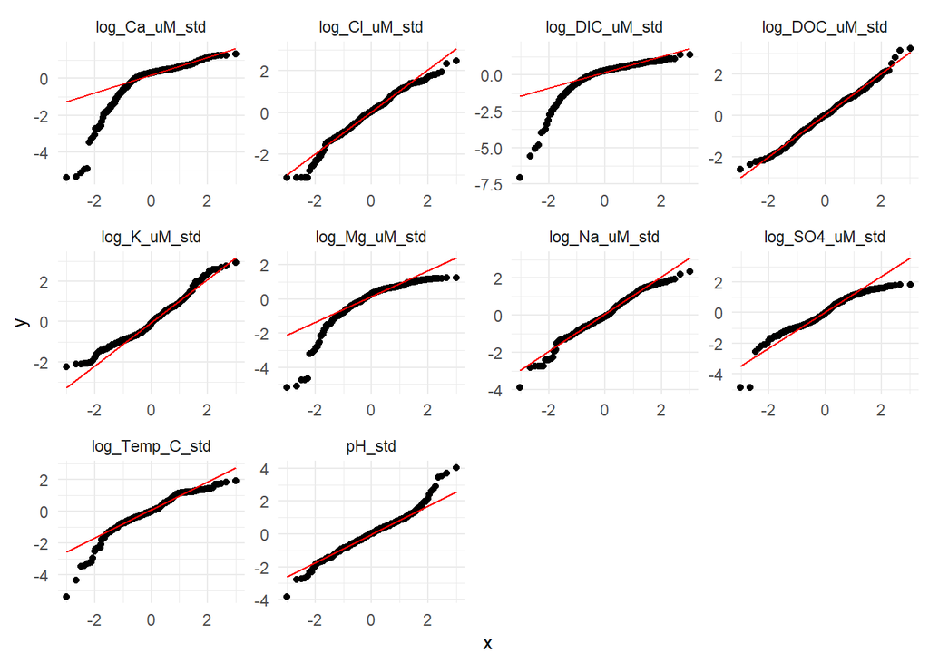

```r
# QQ plots

# Load libraries
library(ggplot2)
library(tidyr)

dr_long <- scaled_blm_predict %>%
  pivot_longer(cols = everything(), names_to = "variable", values_to = "value")

ggplot(dr_long, aes(sample = value)) +
  stat_qq() +
  stat_qq_line(color = "red") +
  facet_wrap(~ variable, scales = "free") +
  theme_minimal()
```

### b. Spearman Correlation Matrix

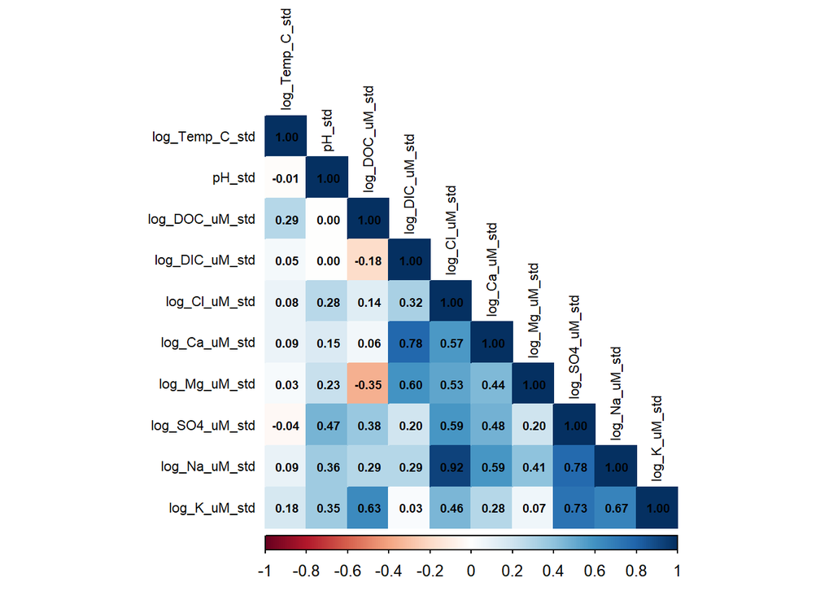

```r
# Spearman correlation matrix on scaled log BLM predictors
cor_matrix <- cor(scaled_blm_predict, method="spearman")

# Heatmap
library(corrplot)
corrplot(cor_matrix,
         method = "color",
         type = "lower",
         tl.cex = 0.7,
         tl.col = "black",
         addCoef.col = "black",
         number.cex = 0.6)
```

Save to excel

```r
library(openxlsx)

# ----------------------------------------------------------
# 1. File name
# ----------------------------------------------------------
file_path <- "Statistical_analyses_all_sites.xlsx"

# ----------------------------------------------------------
# 2. Load workbook if exists, otherwise create a new one
# ----------------------------------------------------------
if (file.exists(file_path)) {
  wb <- loadWorkbook(file_path)
} else {
  wb <- createWorkbook()
}

# ----------------------------------------------------------
# 3. Create sheet if it does NOT exist
# ----------------------------------------------------------
if (!"Spear Corr" %in% names(wb)) {
  addWorksheet(wb, "Spear Corr")
}

# ----------------------------------------------------------
# 4. Write data to the sheet
# ----------------------------------------------------------
writeData(wb, "Spear Corr", cor_matrix)

# ----------------------------------------------------------
# 5. Save workbook (overwrite = TRUE allows updating)
# ----------------------------------------------------------
saveWorkbook(wb, file_path, overwrite = TRUE)
```

Note that Cl and Na are highly correlated, others are acceptable

### c. **KMO Adequacy Test**

```r
library(psych)

# Scaled predictors
KMO(scaled_blm_predict)
```

```
## Kaiser-Meyer-Olkin factor adequacy
## Call: KMO(r = scaled_blm_predict)
## Overall MSA =  0.72
## MSA for each item =
## log_Temp_C_std         pH_std log_DOC_uM_std log_DIC_uM_std  log_Cl_uM_std
##           0.43           0.79           0.49           0.71           0.68
##  log_Ca_uM_std  log_Mg_uM_std log_SO4_uM_std  log_Na_uM_std   log_K_uM_std
##           0.75           0.77           0.84           0.69           0.70
```